# Smart Typing Machine Shiny App

10/16/2019

## Smart Typing Machine

This Shiny app was built for the Coursera/Johns Hopkins Data Science Capstone to showcase the habilities learned in the program.

The app presents to you an “omnibox” where you can start typing, and it will help you:

- at all times it will suggest the next word
- it will autocomplete the word you are typing right now

That way you can type much faster while saving a few keystrokes.

You can also paste in some text just to check the predictions.

## Under the hood (1/2)

A simple app, but its predictions are based on a powerful 5-gram probabilistic model, built from the Coursera/SwiftKey dataset containing thousands of tweets, blog posts and news articles.

Upon this model, we implemented a Stupid Backoff-type algorithm:

- Given the last 4 words, the algorithm looks for the most frequent 5-grams starting with such words
- If it can’t find them, we use the last 3 words to predict from the 4-grams
- And so on if it keeps failing until predicting by the frequency of single words as a last resort.

## Under the hood (2/2)

We pre-computed the 5 most likely next words for each known n-gram and stored in the model, for an improved response time in our application. Here are our results from a popular benchmark on the discussion forums:

```r
Overall top-3 score:     17.60 %
Overall top-1 precision: 13.18 %
Overall top-3 precision: 21.47 %
Average runtime:         27.07 msec
Number of predictions:   28464
Total memory used:       1.38 MB

Dataset details
 Dataset "blogs" (599 lines, 14587 words, hash 14b3c593e543eb8b2932cf00b646ed653e336897a03c82098b725e6e1f9b7aa2)
  Score: 17.37 %, Top-1 precision: 12.88 %, Top-3 precision: 21.35 %
 Dataset "tweets" (793 lines, 14071 words, hash 7fa3bf921c393fe7009bc60971b2bb8396414e7602bb4f409bed78c7192c30f4)
  Score: 17.83 %, Top-1 precision: 13.47 %, Top-3 precision: 21.59 %
```

## Sample results

For a little demonstration of the working app, look at the suggestions after you type “cousera is the”…

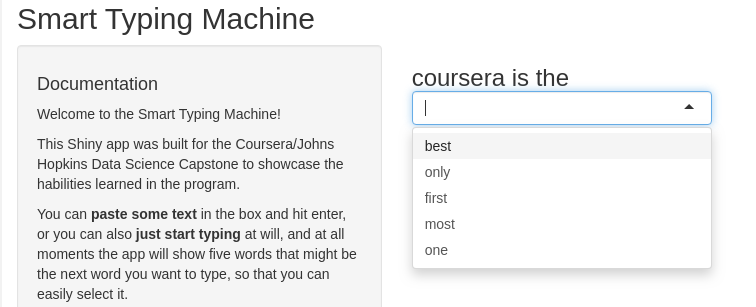

Enjoy the app!

https://vitorcd.shinyapps.io/smart-typing-machine/